# NYCv4-Copy5

```python
indian_rest_stats_ny.head()
```

|  | Borough | Neighborhood | ID | Name | Likes | Rating | Tips |
| --- | --- | --- | --- | --- | --- | --- | --- |
| 0 | Bronx | Woodlawn | 4c0448d9310fc9b6bf1dc761 | Curry Spot | 4 | 8.0 | 11 |
| 1 | Bronx | Parkchester | 4c194631838020a13e78e561 | Melanies Roti Bar And Grill | 3 | 6.3 | 2 |
| 2 | Bronx | Spuyten Duyvil | 4c04544df423a593ac83d116 | Cumin Indian Cuisine | 13 | 6.1 | 9 |
| 3 | Bronx | Concourse | 551b7f75498e86c00a0ed2e1 | Hungry Bird | 8 | 7.4 | 3 |
| 4 | Bronx | Unionport | 4c194631838020a13e78e561 | Melanies Roti Bar And Grill | 3 | 6.3 | 2 |

```python
indian_rest_stats_ny.shape
```

```
(146, 7)
```

```python
indian_rest_ny.shape
```

```
(146, 4)
```

```python
indian_rest_stats_ny.to_csv('indian_rest_stats_ny.csv', index=False)
```

```python
indian_rest_stats_ny_csv=pd.read_csv('indian_rest_stats_ny.csv')
```

```python
indian_rest_stats_ny_csv.shape
```

```
(146, 7)
```

```python
indian_rest_stats_ny_csv.head()
```

|  | Borough | Neighborhood | ID | Name | Likes | Rating | Tips |
| --- | --- | --- | --- | --- | --- | --- | --- |
| 0 | Bronx | Woodlawn | 4c0448d9310fc9b6bf1dc761 | Curry Spot | 4 | 8.0 | 11 |
| 1 | Bronx | Parkchester | 4c194631838020a13e78e561 | Melanies Roti Bar And Grill | 3 | 6.3 | 2 |
| 2 | Bronx | Spuyten Duyvil | 4c04544df423a593ac83d116 | Cumin Indian Cuisine | 13 | 6.1 | 9 |
| 3 | Bronx | Concourse | 551b7f75498e86c00a0ed2e1 | Hungry Bird | 8 | 7.4 | 3 |
| 4 | Bronx | Unionport | 4c194631838020a13e78e561 | Melanies Roti Bar And Grill | 3 | 6.3 | 2 |

```python
indian_rest_stats_ny.info()
```

```
<class 'pandas.core.frame.DataFrame'>
RangeIndex: 146 entries, 0 to 145
Data columns (total 7 columns):
Borough         146 non-null object
Neighborhood    146 non-null object
ID              146 non-null object
Name            146 non-null object
Likes           146 non-null object
Rating          146 non-null float64
Tips            146 non-null object
dtypes: float64(1), object(6)
memory usage: 8.1+ KB
```

```python
indian_rest_stats_ny['Likes']=indian_rest_stats_ny['Likes'].astype('float64')
```

```python
indian_rest_stats_ny['Tips']=indian_rest_stats_ny['Tips'].astype('float64')
```

```python
indian_rest_stats_ny.info()
```

```
<class 'pandas.core.frame.DataFrame'>
RangeIndex: 146 entries, 0 to 145
Data columns (total 7 columns):
Borough         146 non-null object
Neighborhood    146 non-null object
ID              146 non-null object
Name            146 non-null object
Likes           146 non-null float64
Rating          146 non-null float64
Tips            146 non-null float64
dtypes: float64(3), object(4)
memory usage: 8.1+ KB
```

```python
# Restaurants with maximum Likes
indian_rest_stats_ny.iloc[indian_rest_stats_ny['Likes'].idxmax()]
```

```
Borough                        Manhattan
Neighborhood                     Midtown
ID              49d91c12f964a520015e1fe3
Name               The Kati Roll Company
Likes                                832
Rating                               8.8
Tips                                 258
Name: 42, dtype: object
```

```python
# Restaurants with maximum Rating
indian_rest_stats_ny.iloc[indian_rest_stats_ny['Rating'].idxmax()]
```

```
Borough                        Manhattan
Neighborhood                     Tribeca
ID              4bbb9dbded7776b0e1ad3e51
Name                    Tamarind TriBeCa
Likes                                581
Rating                                 9
Tips                                 145
Name: 45, dtype: object
```

```python
# Restaurants with maximum Tips
indian_rest_stats_ny.iloc[indian_rest_stats_ny['Tips'].idxmax()]
```

```
Borough                        Manhattan
Neighborhood                     Midtown
ID              49d91c12f964a520015e1fe3
Name               The Kati Roll Company
Likes                                832
Rating                               8.8
Tips                                 258
Name: 42, dtype: object
```

```python
ny_neighborhood_stats=indian_rest_stats_ny.groupby('Neighborhood',as_index=False).mean()[['Neighborhood','Rating']]
ny_neighborhood_stats.columns=['Neighborhood','Average Rating']
```

```python
ny_neighborhood_stats.sort_values(['Average Rating'],ascending=False).head(10)
```

|  | Neighborhood | Average Rating |
| --- | --- | --- |
| 70 | Tribeca | 9.00 |
| 47 | Murray Hill | 8.80 |
| 44 | Midtown | 8.80 |
| 76 | West Village | 8.75 |
| 50 | North Side | 8.70 |
| 10 | Chelsea | 8.70 |
| 63 | South Side | 8.70 |
| 25 | Fort Greene | 8.60 |
| 79 | Yorkville | 8.50 |
| 62 | Roosevelt Island | 8.40 |

```python
ny_borough_stats=indian_rest_stats_ny.groupby('Borough',as_index=False).mean()[['Borough','Rating']]
ny_borough_stats.columns=['Borough','Average Rating']
```

```python
ny_borough_stats.sort_values(['Average Rating'],ascending=False).head()
```

|  | Borough | Average Rating |
| --- | --- | --- |
| 1 | Brooklyn | 5.968966 |
| 0 | Bronx | 5.683333 |
| 2 | Manhattan | 4.300000 |
| 3 | Queens | 0.000000 |
| 4 | Staten Island | 0.000000 |

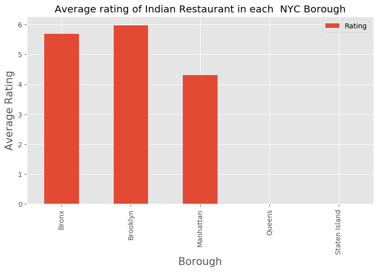

```python
plt.figure(figsize=(9,5), dpi = 100)
# title
plt.title('Average rating of Indian Restaurant in each  NYC Borough')
#On x-axis
plt.xlabel('Borough', fontsize = 15)
#On y-axis
plt.ylabel('Average Rating', fontsize=15)
#giving a bar plot
indian_rest_stats_ny.groupby('Borough').mean()['Rating'].plot(kind='bar')
#legend
plt.legend()
#displays the plot
plt.show()
```

Brooklyn has the highest average rating for Indian Restaurants.

###### All the neighborhoods with average rating greater or equal 8.0 to be visualized on map

```python
ny_neighborhood_stats=ny_neighborhood_stats[ny_neighborhood_stats['Average Rating']>=8.0]
```

```python
ny_neighborhood_stats
```

|  | Neighborhood | Average Rating |
| --- | --- | --- |
| 9 | Central Harlem | 8.10 |
| 10 | Chelsea | 8.70 |
| 13 | Clinton Hill | 8.35 |
| 17 | East Flatbush | 8.30 |
| 25 | Fort Greene | 8.60 |
| 44 | Midtown | 8.80 |
| 47 | Murray Hill | 8.80 |
| 50 | North Side | 8.70 |
| 51 | Ocean Hill | 8.25 |
| 62 | Roosevelt Island | 8.40 |
| 63 | South Side | 8.70 |
| 70 | Tribeca | 9.00 |
| 74 | Upper West Side | 8.20 |
| 76 | West Village | 8.75 |
| 77 | Woodlawn | 8.00 |
| 79 | Yorkville | 8.50 |

```python
ny_neighborhood_stats=pd.merge(ny_neighborhood_stats,new_york_data, on='Neighborhood')
```

```python
ny_neighborhood_stats=ny_neighborhood_stats[['Borough','Neighborhood','Latitude','Longitude','Average Rating']]
```

```python
ny_neighborhood_stats.sort_values(['Average Rating'],ascending=False).head(10)
```

|  | Borough | Neighborhood | Latitude | Longitude | Average Rating |
| --- | --- | --- | --- | --- | --- |
| 13 | Manhattan | Tribeca | 40.721522 | -74.010683 | 9.00 |
| 6 | Manhattan | Midtown | 40.754691 | -73.981669 | 8.80 |
| 7 | Manhattan | Murray Hill | 40.748303 | -73.978332 | 8.80 |
| 8 | Queens | Murray Hill | 40.764126 | -73.812763 | 8.80 |
| 15 | Manhattan | West Village | 40.734434 | -74.006180 | 8.75 |
| 9 | Brooklyn | North Side | 40.714823 | -73.958809 | 8.70 |
| 12 | Brooklyn | South Side | 40.710861 | -73.958001 | 8.70 |
| 2 | Staten Island | Chelsea | 40.594726 | -74.189560 | 8.70 |
| 1 | Manhattan | Chelsea | 40.744035 | -74.003116 | 8.70 |
| 5 | Brooklyn | Fort Greene | 40.688527 | -73.972906 | 8.60 |

```python
# create map and display it
ny_map = folium.Map(location=(40.693943, -73.985880), zoom_start=12)
```

```python
# instantiate a feature group for the incidents in the dataframe
incidents = folium.map.FeatureGroup()

# loop through the 100 crimes and add each to the incidents feature group
for lat, lng, in ny_neighborhood_stats[['Latitude','Longitude']].values:
    incidents.add_child(
        folium.CircleMarker(
            [lat, lng],
            radius=10, # define how big you want the circle markers to be
            color='yellow',
            fill=True,
            fill_color='blue',
            fill_opacity=0.6
        )
    )
```

```python
ny_neighborhood_stats['Label']=ny_neighborhood_stats['Neighborhood']+', '+ny_neighborhood_stats['Borough']+'('+ny_neighborhood_stats['Average Rating'].map(str)+')'
```

##### Best neighbourhoods in New York that has highest average rating for Indian Restaurants.

```python
# add pop-up text to each marker on the map
for lat, lng, label in ny_neighborhood_stats[['Latitude','Longitude','Label']].values:
    folium.Marker([lat, lng], popup=label).add_to(ny_map)
# add incidents to map
ny_map.add_child(incidents)
```

[interactive chart not shown]

Findings

##### Recommendation

Midtown or Tribeca in Manhattan would be the best choice to start a restaurant given that

1. it is the third most populous urban area in New York City (NYC).
2. it has a population density of 27,826 people per square km, highest of any borough in the United States.
3. it has some of the top rated Indian restaurants located in that area
4. It has the second highest Asian ethnic minority population in NYC.